# Mini-Dissertation Write-up Guide

Part 02 - Method Section

Dr. Gordon Wright

g.wright@gold.ac.uk

January 15, 2024

# Method Section

**Learning Objectives**

1. Review the key features of a complete Method section in APA reports
2. Identify key information required for each sub-section in the Mini-Dissertation method section
3. Offset common errors and ensure good pre-submission checking

## Talking Methods

In this chapter, you will learn how to craft a comprehensive and clear Methods section for your mini-dissertation. The Method section is not just a procedural description but a showcase of your meticulous planning and execution of research, adhering to the principles of Open Science by also attaching an Open Materials submission (to be covered later in detail).

## Method

The method section is where you describe how you conducted your study. An important principle for writing a method section is that it should be clear and detailed enough that other researchers could replicate the study by following your “recipe.” This means that it must describe all the important elements of the study—basic demographic characteristics of the participants, how they were recruited, whether they were randomly assigned, how the variables were manipulated or measured, how counterbalancing was accomplished, and so on. At the same time, it should avoid irrelevant details such as the fact that the study was conducted in Classroom 37B of the Industrial Technology Building or that the questionnaire was double-sided and completed using mechanical pencils.

**APA Style and the Values of Psychology**

Robert Madigan and his colleagues have argued that APA style has a purpose that often goes unrecognized (Madigan et al., 1995). Specifically, it promotes psychologists’ scientific values and assumptions. From this perspective, many features of APA style that at first seem arbitrary actually make good sense. Following are several features of APA-style writing and the scientific values or assumptions they reflect.

| APA style feature | Scientific value or assumption |
| --- | --- |
| There are very few direct quotations of other researchers. | The phenomena and theories of psychology are objective and do not depend on the specific words a particular researcher used to describe them. |
| Criticisms are directed at other researchers’ work but not at them personally. | The focus of scientific research is on drawing general conclusions about the world, not on the personalities of particular researchers. |
| There are many references and reference citations. | Scientific research is a large-scale collaboration among many researchers. |
| Empirical research reports are organized with specific sections in a fixed order. | There is an ideal approach to conducting empirical research in psychology (even if this ideal is not always achieved in actual research). |
| Researchers tend to “hedge” their conclusions, e.g., “The results suggest that…” | Scientific knowledge is tentative and always subject to revision based on new empirical results. |

### Purpose of the Method Section

- The Method section is crucial for allowing others to replicate your study, ensuring the reliability and validity of your research findings.
- A well-documented Method section demonstrates your thorough understanding of research methodologies, earning you credibility and potentially higher marks.

### Overview of APA 7 Formatting

- APA7 emphasizes clarity, precision, and a bias-free language in research writing. The simple way of understanding if a Method section is complete and effective is to ask yourself, “Could Gordon take my Method section (and Open Materials) and replicate my study perfectly?”. Don’t include obvious information, such as the colour of ink in pens or stuff I could figure out. Just the important information!
- Consistency in formatting, such as headings, font, and citation style (APA7), is key. If you are unclear on the appropriate format, either use the template Gordon has provided, or refer to apastyle.org for numerous examples.
- Use past tense to describe the methods used: “Participants were asked…”, “The study used…”. You have completed the study after all.

A previous edition of the *Publication Manual* strongly discouraged the use of the term *subjects* (except for nonhumans) and strongly encouraged the use of *participants* instead. But it also encourages the use of more specific terms when possible: *college students*, *children*, *respondents*, and so on. If in doubt, refer to PARTICIPANTS!

Top 10 APA-Style Errors.

| Error type | Example |
| --- | --- |
| 1. Use of numbers | Failing to use numerals for 10 and above |
| 2. Hyphenation | Failing to hyphenate compound adjectives that precede a noun (e.g., “role playing technique” should be “role-playing technique”) |
| 3. Use of et al. | Failing to use it in a reference |
| 4. Headings | Not capitalizing headings correctly |
| 5. Use of since | Using since to mean because |
| 6. Tables and figures | Not formatting them in APA style; repeating information that is already given in the text |
| 7. Use of commas | Failing to use a comma before and or or in a series of three or more elements |
| 8. Use of abbreviations | Failing to spell out a term completely before introducing an abbreviation for it |
| 9. Spacing | Not consistently double-spacing between lines |
| 10. Use of & in references | Using & in the text or *and* in parentheses |

**Online APA Style Resources again 🤓**

The best source of information on APA style is the *Publication Manual* itself. However, there are also many good websites on APA style, which do an excellent job of presenting the basics for beginning researchers. Here are two of them.

APA Style: http://www.apastyle.apa.org

Purdue Online Writing Lab: https://owl.purdue.edu/owl/research_and_citation/apa_style/apa_style_introduction.html

## Participants

In this section, describe who participated in your study, how they were selected or recruited, and any demographic information relevant to your research question. If you used a nice poster, that would look great in your Open Materials submission.

Begin by reporting sample characteristics, sampling procedures, and sample size. Include demographic characteristics and be precise to aid estimation of generalizability. Use bias-free language and specify any incentives for participation.

Please be clear if you took advantage of any research participation schemes or synthetic or fabricated data provided by Gordon.

### Sample Description

- Provide details like age, gender, ethnicity, or other relevant characteristics.
- Example: “The study comprised 100 undergraduate students (50% female, 50% male), aged 18-25, from a South London University.”
- You may also wish to include how many participants were excluded for missing data (if any).

### Ethical Considerations

- Explain how participants gave informed consent and how you protected their privacy. You will be able to demonstrate anonymisation of the data in the Open Data (to be covered later!)
- Mention the ethical approval received from the Goldsmiths Ethics Committee. Don’t break anonymity by including an unredacted copy in any supplementary materials!

## Materials

This section covers the tools, questionnaires, or any equipment used in your research. The goal is to describe the tools and techniques used for measuring ALL relevant variables. Include questionnaire or survey measures, and detail any instruments or task used, like hardware, software, or tests. Don’t repeat information, so if you Procedure section includes the correct step by step information on. say, a task, refer to it by name here maybe, and detail it in the procedure. Or if you think there is value in detailing it here, just refer to it by name in the procedure section.

### Instruments and Reliability

- Describe each tool used and its purpose in your research.
- Discuss the reliability and validity of these tools. It might be worth looking back to your introduction to see if it is worth including any findings associated with the tests you have used. Most people don’t cover the merits of the choice of measurement tools when reviewing previous research.
- Example: “The Big Five Personality Test (reference in APA format), with a Cronbach’s alpha of .82, was used to assess [x, y] personality traits”

### Open Materials

- Briefly note that detailed discussion on Open Materials is covered in a different section, but highlight their importance in enhancing replicability and transparency of research.
- Example: “Details on the questionnaires used, including their full text, are provided in the Open Materials section.”

## Procedure

Detail every step taken in your research, especially how you implemented the 2x2 ANOVA, to allow for replication.

### Detailed Description

- Start from the initial setup and move through to the data collection phase.
- For a 2x2 ANOVA, specify the factors (independent variables) and their levels.
- Example: “Participants were randomly assigned to one of four groups (2x2 design: Factor A [Level one, Level two], Factor B [Level one, Level two]). The response time was measured following the presentation of stimuli.”

### Pilot Studies

- If applicable, describe any pilot study and its influence on the main study.
- Example: “A pilot study with four classmates was conducted to test the feasibility of the experimental design. Based on the pilot results, minor adjustments were made to ensure the clarity of instructions given to participants (see Open Materials for instruction sheet).”

## Design

Explain the research design and clarify the variables involved in your study.

You have 2 IVs and a single continuous DV. It is important to present how your IVs were categorised, so if you used a median split to turn a continuous measure into a categorical IV - make that clear here.

### Research Design

- Emphasize that your study is quantitative and primarily uses a 2x2 ANOVA design.
- You will have used a between-groups design, a repeated-measures design or a mixed design, make this clear, and if mixed, which IV is which!
- It can be a good idea to explain why this design was chosen for your research question.

### Variables

- Define your independent variables (the two factors in your ANOVA - each with 2 levels) and your dependent variable (what you measured).
- Example: “The independent variables were age group (young, old using a median split on Age [median 25 yrs]) and treatment type (treatment, control). The dependent variable was memory recall accuracy (percentage correct).”

## Keeping design and procedure separate!

What is the difference between design and procedure?

- The design of a study is its overall structure.
- What were the independent and dependent variables?
- Was the independent variable manipulated, and if so, was it manipulated between or within subjects?
- How were the variables operationally defined?

The procedure is how the study was carried out.

- It often works well to describe the procedure in terms of what the participants did rather than what the researchers did.
- For example, the participants gave their informed consent, read a set of instructions, completed a block of four practice trials, completed a block of 12 test trials<sup>1</sup>, completed two questionnaires, and were debriefed and excused.
[^1]: Note four and 12 above. See APA Style - One to nine are spelled out, 10 + can be written as digits!

## Data Preparation (optional section if merited)

If you had any complex preprocessing steps, of which you were proud, such as ‘coding’ of responses, or calculating Implicit measures or Stroop results, discuss how you processed that. .

### Statistical Analysis will be covered in the Results section

- This will comprise Descriptive Stats, Inferential stats (including Assumptions tests and post-hoc tests), as well as tables and figures. You do not need to include any of these things in the method section.

### Open Materials and Open Data (to be covered later)

- Mention that Open Materials and Open Data will be included and so can be referred to. Let the reader know that they are available, like appendices.
- Example: “The anonymised dataset generated from this study, along with the Materials necessary to replicate the study, are available in the Open Data & Open Materials supplements, ensuring transparency and reproducibility of the findings.”

### Ethical Compliance

- Describe the process of obtaining ethical clearance and how you adhered to ethical guidelines throughout the study.
- Example: “Ethical clearance was obtained from the XYZ University Ethics Committee, and all research activities were conducted in accordance with appropriate Ethics committee and BPS guidance.”

## Writing Style and Formatting

Guidelines for effectively communicating your methods in line with APA 7 standards.

**Tips for Writing**

**Common Mistakes to Avoid**

- Overloading with unnecessary details that do not contribute to replicability.
- Failing to use **bias-free language**.
- Not being precise in the description of materials and procedures, including references or sources.
- Incorrect use of **APA formatting and style**, especially in headings and subheadings.

### Method Section Awesomeness Checklist

#### 1. Formatting and Structure

- Main heading (“Method”) is centered, bold, and capitalized.
- Subheadings (e.g., “Participants,” “Materials,” “Procedure”) are left-aligned, bold, and in title case.

#### 2. Participants

- Detailed description of participant characteristics (age, gender, ethnicity, etc.).
- Explanation of sampling procedures and selection criteria.
- Reporting of sample size and explanation of how it was determined.
- Mention of any compensation or incentives for participation.
- Use of bias-free language.

#### 3. Materials

- Comprehensive list of materials, tools, and equipment used.
- Detailed description of measures and instruments (including versions of software, etc.).
- Explanation of the reliability and validity of measurement tools.

#### 4. Procedure

- Step-by-step description of the experimental procedure.
- Explanation of data collection methods.
- Details on research design and methodologies used.
- Description of data analysis procedures and statistical tests applied.

#### 5. Clarity and Precision

- All terms and concepts are clearly defined.
- The section is written in active voice and past tense.
- Content is relevant and directly related to the study’s replication.

#### 6. APA Compliance

- Adherence to APA style in headings, citations, and overall formatting.
- Correct use of APA format for figures, tables, and appendices (if any).

#### 7. Editing and Proofreading

- The section is thoroughly proofread for grammar, spelling, and punctuation errors.
- All information is accurate and up-to-date.
- The writing is concise and free of unnecessary details.

#### 8. Ethical Considerations

- Mention of ethical approval (if applicable).
- Assurances of participant confidentiality and data handling.

## This is a visual for the headings according to APA7

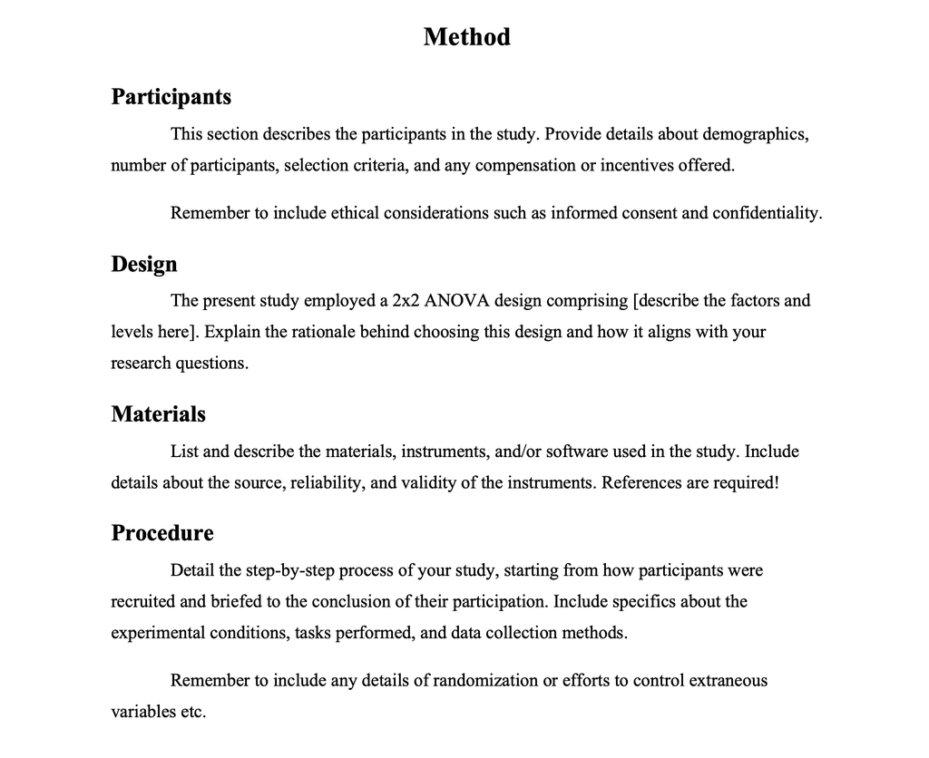

## References

[figure not shown]

Madigan, R., Johnson, S., & Linton, P. (1995). The language of psychology: APA style as epistemology. *American Psychologist*, *50*(6), 428.

Onwuegbuzie, A. J., Combs, J. P., Slate, J. R., & Frels, R. K. (2010). Evidence-based guidelines for avoiding the most common APA errors in journal article submissions. *Research in the Schools*, *16*(2), ix–xxxvi.